# HW #1

Xulin Ge

Jul 08 2023

We will be working with a study from Gene Expression Omnibus (GEO) with the accession GDS2880. This is an Affymetrix microarray experiment (HGU133A array).

The data researchers were investigating patient matched normal and stage 1 or stage 2 clear cell renal cell carcinoma (cRCC) tumors to provide insight into the molecular pathogenesis of cRCC.

We will be conducting outlier analysis using various methods to identify aberrant samples, followed by missing value imputation to assess the accuracy of two different algorithms

```r
# installing/loading the package:
if(!require(gdata)) {
  install.packages("gdata");
  require(gdata)
}
if(!require(impute)) {
  if (!require("BiocManager", quietly = TRUE))
    install.packages("impute")
  BiocManager::install("impute");
  require(impute)
}
if(!require(pcaMethods)) {
  if (!require("BiocManager", quietly = TRUE))
    install.packages("pcaMethods")
  BiocManager::install("pcaMethods");
  require(pcaMethods)
}
```

```r
# Set the directory
(WD <- getwd())
if (!is.null(WD)) setwd(WD)
```

# Read files into R

### Read the renal cell carcinoma data `renal_cell_carcinoma.txt`

Make sure that the row names are in the correct location (Affymetrix fragment names)

```r
# using the read.table() function
data_file <- "renal_cell_carcinoma.txt"
dat <- read.table(file=file.path("data", data_file), header=T, row.names=1)
```

### Look at the dimensions of the data

There should be 22 arrays and 22,283 probesets

```r
dim(dat)
```

```
## [1] 22283    22
```

```r
colnames(dat)
```

```
##  [1] "GSM146778" "GSM146780" "GSM146782" "GSM146784" "GSM146786" "GSM146789"
##  [7] "GSM146790" "GSM146792" "GSM146794" "GSM146798" "GSM146796" "GSM146779"
## [13] "GSM146781" "GSM146783" "GSM146785" "GSM146787" "GSM146788" "GSM146791"
## [19] "GSM146799" "GSM146793" "GSM146795" "GSM146797"
```

```r
knitr::kable(head(dat), caption="renal cell carcinoma data")
```

renal cell carcinoma data

|  | GSM146778 | GSM146780 | GSM146782 | GSM146784 | GSM146786 | GSM146789 | GSM146790 | GSM146792 | GSM146794 | GSM146798 | GSM146796 | GSM146779 | GSM146781 | GSM146783 | GSM146785 | GSM146787 | GSM146788 | GSM146791 | GSM146799 | GSM146793 | GSM146795 | GSM146797 |
| --- | --- | --- | --- | --- | --- | --- | --- | --- | --- | --- | --- | --- | --- | --- | --- | --- | --- | --- | --- | --- | --- | --- |
| 1007_s_at | 1942.1 | 2358.3 | 2465.2 | 2732.9 | 1952.2 | 2048.3 | 2109.0 | 3005.1 | 2568.1 | 9898.34069 | 2107.7 | 1940.2 | 2608.8 | 1837.2 | 1559.2 | 2111.6 | 2641.0 | 1972.7 | 10191.6714 | 1737.2 | 1636.1 | 2718.4 |
| 1053_at | 40.1 | 58.2 | 132.6 | 64.3 | 66.1 | 69.0 | 109.7 | 59.4 | 81.7 | 134.27862 | 100.8 | 170.1 | 186.7 | 103.8 | 86.8 | 86.0 | 152.7 | 124.8 | 213.4835 | 115.0 | 202.1 | 257.3 |
| 117_at | 72.1 | 248.8 | 85.5 | 129.5 | 161.2 | 148.9 | 157.0 | 182.0 | 143.9 | 250.88942 | 160.4 | 104.2 | 252.0 | 262.8 | 204.4 | 217.1 | 291.5 | 182.8 | 264.5375 | 117.5 | 393.1 | 254.6 |
| 121_at | 4693.6 | 7098.2 | 6314.1 | 5038.0 | 6012.4 | 6472.8 | 6940.4 | 10609.7 | 6942.7 | 8088.44906 | 6864.9 | 3597.0 | 3143.7 | 2253.3 | 2835.4 | 3746.1 | 4563.5 | 4245.3 | 8672.7648 | 2875.1 | 3443.0 | 4103.6 |
| 1255_g_at | 35.9 | 97.3 | 22.4 | 23.0 | 85.1 | 9.6 | 45.1 | 110.3 | 34.2 | 15.54649 | 91.2 | 55.7 | 19.1 | 53.0 | 25.6 | 50.3 | 12.2 | 50.3 | 73.0361 | 47.4 | 66.3 | 97.8 |
| 1294_at | 546.8 | 479.8 | 426.3 | 591.0 | 402.6 | 524.6 | 444.5 | 469.6 | 495.9 | 500.76858 | 334.4 | 678.5 | 503.6 | 615.4 | 364.9 | 418.4 | 495.9 | 274.9 | 424.3073 | 457.5 | 447.5 | 395.9 |

### Read the annotation file `renal_carcinoma_annotation.txt`

```r
ann_file <- "renal_carcinoma_annotation.txt"
ann <- read.table(file=file.path("data", ann_file))
knitr::kable(head(ann), caption="renal cell carcinoma annotation")
```

renal cell carcinoma annotation

| V1 | V2 | V3 | V4 | V5 | V6 | V7 | V8 | V9 | V10 | V11 | V12 | V13 | V14 |
| --- | --- | --- | --- | --- | --- | --- | --- | --- | --- | --- | --- | --- | --- |
| GSM146778 | = | Value | for | GSM146778: | Stage | 1, | PT2, | Normal | (HG-U133A); | src: | Human | Renal | Epithelium |
| GSM146780 | = | Value | for | GSM146780: | Stage | 1, | PT3, | Normal | (HG-U133A); | src: | Human | Renal | Epithelium |
| GSM146782 | = | Value | for | GSM146782: | Stage | 1, | PT4, | Normal | (HG-U133A); | src: | Human | Renal | Epithelium |
| GSM146784 | = | Value | for | GSM146784: | Stage | 1, | PT5, | Normal | (HG-U133A); | src: | Human | Renal | Epithelium |
| GSM146786 | = | Value | for | GSM146786: | Stage | 1, | PT6, | Normal | (HG-U133A); | src: | Human | Renal | Epithelium |
| GSM146789 | = | Value | for | GSM146789: | Stage | 2, | PT8, | Normal | (HG-U133A); | src: | Human | Renal | Epithelium |

### Label the header columns of the data frame maintaining the GSM ID, but adding the Normal/Tumor identity

```r
# Label the header columns by adding the Normal/Tumor identity
old_headers <- colnames(dat)
indices <- match(old_headers, ann["V1"][,1])
new_headers <- list()
for(i in 1:length(old_headers)) {
    index <- indices[i]
    new_header <- paste(ann["V1"][index,], ann["V9"][index,], sep=" ")
    new_headers[i] <- new_header
}
# assigning new names to the columns of the data frame
colnames(dat) <- unlist(new_headers)
colnames(dat)
```

```
##  [1] "GSM146778 Normal" "GSM146780 Normal" "GSM146782 Normal" "GSM146784 Normal"
##  [5] "GSM146786 Normal" "GSM146789 Normal" "GSM146790 Normal" "GSM146792 Normal"
##  [9] "GSM146794 Normal" "GSM146798 Normal" "GSM146796 Normal" "GSM146779 Tumor"
## [13] "GSM146781 Tumor"  "GSM146783 Tumor"  "GSM146785 Tumor"  "GSM146787 Tumor"
## [17] "GSM146788 Tumor"  "GSM146791 Tumor"  "GSM146799 Tumor"  "GSM146793 Tumor"
## [21] "GSM146795 Tumor"  "GSM146797 Tumor"
```

```r
knitr::kable(head(dat), caption="labeled dataset")
```

labeled dataset

|  | GSM146778 Normal | GSM146780 Normal | GSM146782 Normal | GSM146784 Normal | GSM146786 Normal | GSM146789 Normal | GSM146790 Normal | GSM146792 Normal | GSM146794 Normal | GSM146798 Normal | GSM146796 Normal | GSM146779 Tumor | GSM146781 Tumor | GSM146783 Tumor | GSM146785 Tumor | GSM146787 Tumor | GSM146788 Tumor | GSM146791 Tumor | GSM146799 Tumor | GSM146793 Tumor | GSM146795 Tumor | GSM146797 Tumor |
| --- | --- | --- | --- | --- | --- | --- | --- | --- | --- | --- | --- | --- | --- | --- | --- | --- | --- | --- | --- | --- | --- | --- |
| 1007_s_at | 1942.1 | 2358.3 | 2465.2 | 2732.9 | 1952.2 | 2048.3 | 2109.0 | 3005.1 | 2568.1 | 9898.34069 | 2107.7 | 1940.2 | 2608.8 | 1837.2 | 1559.2 | 2111.6 | 2641.0 | 1972.7 | 10191.6714 | 1737.2 | 1636.1 | 2718.4 |
| 1053_at | 40.1 | 58.2 | 132.6 | 64.3 | 66.1 | 69.0 | 109.7 | 59.4 | 81.7 | 134.27862 | 100.8 | 170.1 | 186.7 | 103.8 | 86.8 | 86.0 | 152.7 | 124.8 | 213.4835 | 115.0 | 202.1 | 257.3 |
| 117_at | 72.1 | 248.8 | 85.5 | 129.5 | 161.2 | 148.9 | 157.0 | 182.0 | 143.9 | 250.88942 | 160.4 | 104.2 | 252.0 | 262.8 | 204.4 | 217.1 | 291.5 | 182.8 | 264.5375 | 117.5 | 393.1 | 254.6 |
| 121_at | 4693.6 | 7098.2 | 6314.1 | 5038.0 | 6012.4 | 6472.8 | 6940.4 | 10609.7 | 6942.7 | 8088.44906 | 6864.9 | 3597.0 | 3143.7 | 2253.3 | 2835.4 | 3746.1 | 4563.5 | 4245.3 | 8672.7648 | 2875.1 | 3443.0 | 4103.6 |
| 1255_g_at | 35.9 | 97.3 | 22.4 | 23.0 | 85.1 | 9.6 | 45.1 | 110.3 | 34.2 | 15.54649 | 91.2 | 55.7 | 19.1 | 53.0 | 25.6 | 50.3 | 12.2 | 50.3 | 73.0361 | 47.4 | 66.3 | 97.8 |
| 1294_at | 546.8 | 479.8 | 426.3 | 591.0 | 402.6 | 524.6 | 444.5 | 469.6 | 495.9 | 500.76858 | 334.4 | 678.5 | 503.6 | 615.4 | 364.9 | 418.4 | 495.9 | 274.9 | 424.3073 | 457.5 | 447.5 | 395.9 |

# Identify any outlier samples using the following visual plots

```r
# Load the packages
library(gplots)
```

### Correlation plot (heat map)

Provide a legend for the correlation plot

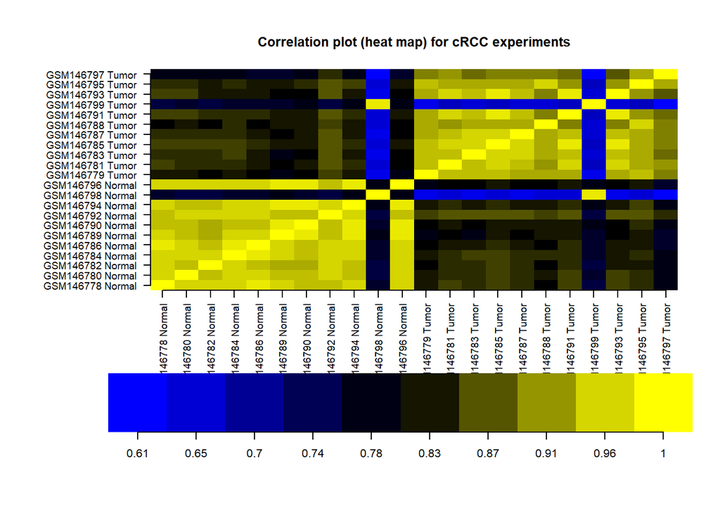

```r
# Compute correlation matrix
dat.cor <- cor(dat, use="pairwise.complete.obs")

# Correlation plot (heat map)
layout(matrix(c(1,1,1,1,1,1,1,1,2,2), 5, 2, byrow = TRUE))
par(oma=c(5,7,1,1))
cx <- rev(colorpanel(25,"yellow","black","blue"))
leg <- seq(min(dat.cor, na.rm=T), max(dat.cor, na.rm=T), length=10)
# title the plot,
image(dat.cor,
  main="Correlation plot (heat map) for cRCC experiments", axes=F, col=cx)
# label the axes
axis(1, at=seq(0,1,length=ncol(dat.cor)),
  label=dimnames(dat.cor)[[2]], cex.axis=0.9, las=2)
axis(2, at=seq(0,1,length=ncol(dat.cor)),
  label=dimnames(dat.cor)[[2]], cex.axis=0.9, las=2)
# provide a legend of the color gradient
# To fix the error: figure margins too large, expand the plot panel
par(mar=c(1,1,1,1))
image(as.matrix(leg), col=cx, axes=F)
tmp <- round(leg,2)
axis(1, at=seq(0,1, length=length(leg)), labels=tmp, cex.axis=1)
```

### Hierarchical clustering dendrogram

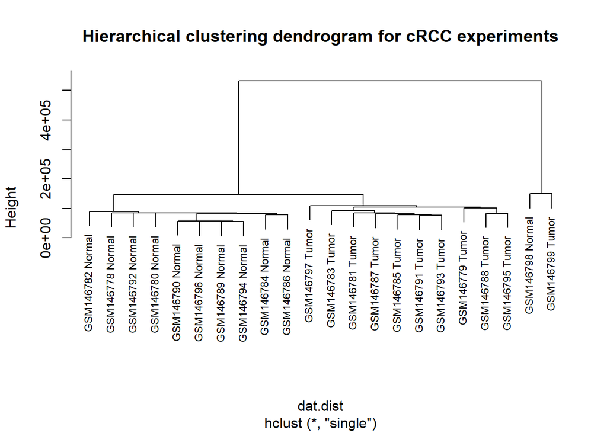

```r
# cluster tree
t_dat <- t(dat) #transpose dat
dat.dist <- dist(t_dat,method="euclidean") # calculate distance
dat.clust <- hclust(dat.dist,method="single") # calculate clusters
plot(dat.clust, labels=names(t_dat), cex=0.75,
  main="Hierarchical clustering dendrogram for cRCC experiments") # plot cluster tree
```

### CV vs. mean plot

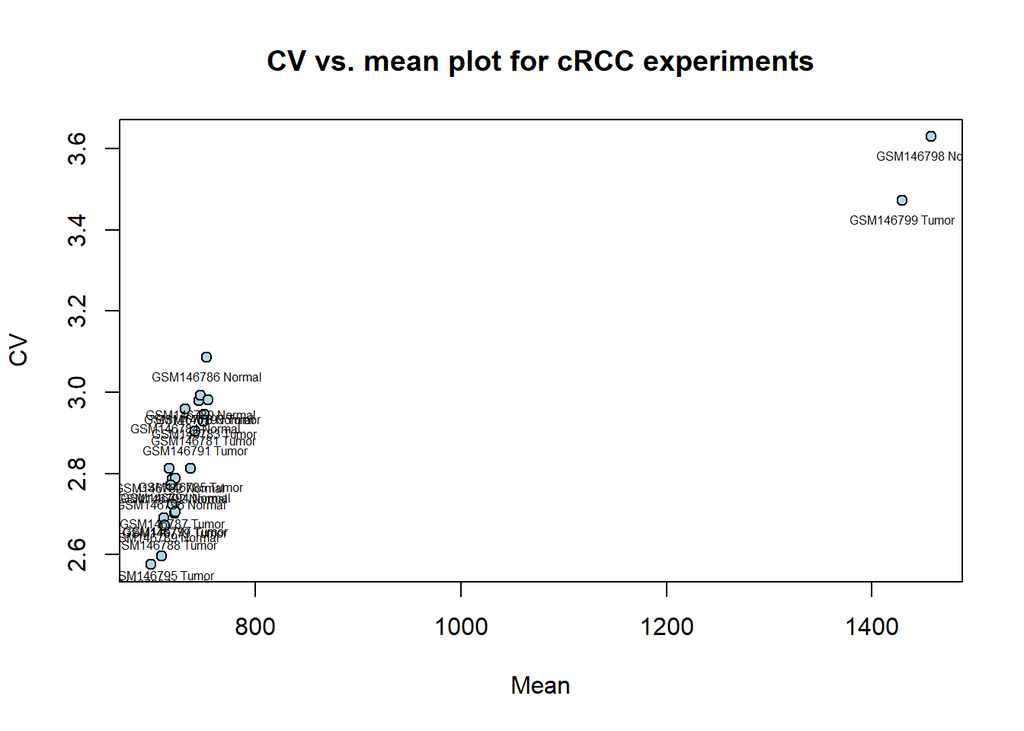

```r
dat.mean <- apply(dat,2,mean) # calculate mean for each sample
dat.sd <- apply(dat,2,sd) # calculate st.deviation for each sample
dat.cv <- dat.sd/dat.mean #calculate cv
plot(dat.mean,dat.cv, xlab="Mean",ylab="CV",col='blue',cex=1.5,type="n",
  main="CV vs. mean plot for cRCC experiments")
points(dat.mean,dat.cv,bg="lightblue",col=1,pch=21)
text(dat.mean,dat.cv,label=dimnames(dat)[[2]],pos=1,cex=0.5)
```

### Average correlation plot

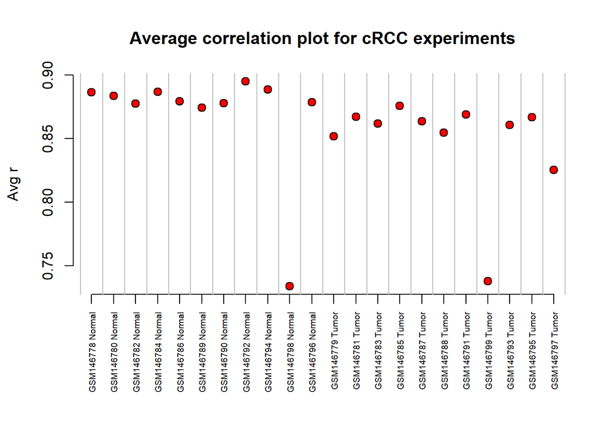

```r
dat.avg <- apply(dat.cor,1,mean)
par(oma=c(3,0.1,0.1,0.1))
plot(c(1,length(dat.avg)),range(dat.avg),type="n",xlab="",ylab="Avg r",
  main="Average correlation plot for cRCC experiments",axes=F)
points(dat.avg,bg="red",col=1,pch=21,cex=1.25)
axis(1,at=c(1:length(dat.avg)),labels=dimnames(dat)[[2]],las=2,cex.lab=0.4,cex.axis=0.6)
axis(2)
abline(v=seq(0.5,62.5,1),col="grey")
```

By looking at these plots, samples “GSM146798 Normal” and “GSM146799 Tumor” are outliers

# Remove the outlier samples identified above

Load the impute library

```r
# Load the packages
library(impute)
```

Remove the outlier samples

```r
outliers <- c("GSM146798 Normal", "GSM146799 Tumor")
dat2 <- dat[ -match(outliers, colnames(dat)) ]
colnames(dat2)
```

```
##  [1] "GSM146778 Normal" "GSM146780 Normal" "GSM146782 Normal" "GSM146784 Normal"
##  [5] "GSM146786 Normal" "GSM146789 Normal" "GSM146790 Normal" "GSM146792 Normal"
##  [9] "GSM146794 Normal" "GSM146796 Normal" "GSM146779 Tumor"  "GSM146781 Tumor"
## [13] "GSM146783 Tumor"  "GSM146785 Tumor"  "GSM146787 Tumor"  "GSM146788 Tumor"
## [17] "GSM146791 Tumor"  "GSM146793 Tumor"  "GSM146795 Tumor"  "GSM146797 Tumor"
```

```r
knitr::kable(head(dat2))
```

|  | GSM146778 Normal | GSM146780 Normal | GSM146782 Normal | GSM146784 Normal | GSM146786 Normal | GSM146789 Normal | GSM146790 Normal | GSM146792 Normal | GSM146794 Normal | GSM146796 Normal | GSM146779 Tumor | GSM146781 Tumor | GSM146783 Tumor | GSM146785 Tumor | GSM146787 Tumor | GSM146788 Tumor | GSM146791 Tumor | GSM146793 Tumor | GSM146795 Tumor | GSM146797 Tumor |
| --- | --- | --- | --- | --- | --- | --- | --- | --- | --- | --- | --- | --- | --- | --- | --- | --- | --- | --- | --- | --- |
| 1007_s_at | 1942.1 | 2358.3 | 2465.2 | 2732.9 | 1952.2 | 2048.3 | 2109.0 | 3005.1 | 2568.1 | 2107.7 | 1940.2 | 2608.8 | 1837.2 | 1559.2 | 2111.6 | 2641.0 | 1972.7 | 1737.2 | 1636.1 | 2718.4 |
| 1053_at | 40.1 | 58.2 | 132.6 | 64.3 | 66.1 | 69.0 | 109.7 | 59.4 | 81.7 | 100.8 | 170.1 | 186.7 | 103.8 | 86.8 | 86.0 | 152.7 | 124.8 | 115.0 | 202.1 | 257.3 |
| 117_at | 72.1 | 248.8 | 85.5 | 129.5 | 161.2 | 148.9 | 157.0 | 182.0 | 143.9 | 160.4 | 104.2 | 252.0 | 262.8 | 204.4 | 217.1 | 291.5 | 182.8 | 117.5 | 393.1 | 254.6 |
| 121_at | 4693.6 | 7098.2 | 6314.1 | 5038.0 | 6012.4 | 6472.8 | 6940.4 | 10609.7 | 6942.7 | 6864.9 | 3597.0 | 3143.7 | 2253.3 | 2835.4 | 3746.1 | 4563.5 | 4245.3 | 2875.1 | 3443.0 | 4103.6 |
| 1255_g_at | 35.9 | 97.3 | 22.4 | 23.0 | 85.1 | 9.6 | 45.1 | 110.3 | 34.2 | 91.2 | 55.7 | 19.1 | 53.0 | 25.6 | 50.3 | 12.2 | 50.3 | 47.4 | 66.3 | 97.8 |
| 1294_at | 546.8 | 479.8 | 426.3 | 591.0 | 402.6 | 524.6 | 444.5 | 469.6 | 495.9 | 334.4 | 678.5 | 503.6 | 615.4 | 364.9 | 418.4 | 495.9 | 274.9 | 457.5 | 447.5 | 395.9 |

# Assess gene kininogen 1 (KNG1) and aquaporin 2 (AQP2)

### Extract the probesets for these two genes. Hint: KNG1 has two while AQP2 has one.

By using BioMart on Ensembl, the probeset ids are shown as

`KNG1 - 206054_at, 217512_at`

`AQP2 - 206672_at`

https://www.biostars.org/p/144117/

https://uswest.ensembl.org/info/data/biomart/index.html

```r
KNG1_1 <- dat2["206054_at",]
KNG1_2 <- dat2["217512_at",]
AQP2_1 <- dat2["206672_at",]
samples <- colnames(dat2)
x1 <- c(1:length(samples))
```

### Plot a profile plot (expression intensity vs. samples) for each probeset for these two genes

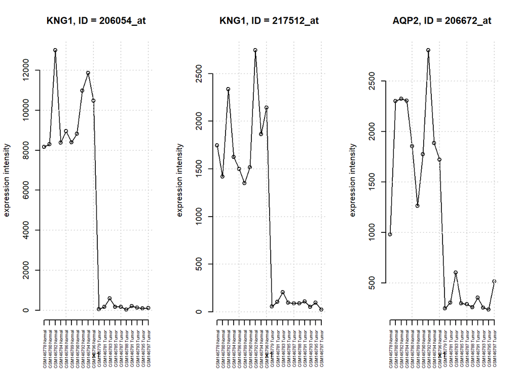

```r
par(mfcol=c(1,3))

# KNG1 206054_at
plot(x1, as.numeric(KNG1_1), ylab="expression intensity",
    main="KNG1, ID = 206054_at", axes=F
    ) + lines(x1, as.numeric(KNG1_1)) + grid()
axis(1, at=x1, labels=samples, las=2, cex.lab=0.8, cex.axis=0.5)
axis(2)

# KNG1_2 217512_at
plot(x1, as.numeric(KNG1_2), ylab="expression intensity",
    main="KNG1, ID = 217512_at", axes=F
    ) + lines(x1, as.numeric(KNG1_2)) + grid()
axis(1, at=x1, labels=samples, las=2, cex.lab=0.8, cex.axis=0.5)
axis(2)

# AQP2_1 206672_at
plot(x1, as.numeric(AQP2_1), ylab="expression intensity",
    main="AQP2, ID = 206672_at", axes=F
    ) + lines(x1, as.numeric(AQP2_1)) + grid()
axis(1, at=x1, labels=samples, las=2, cex.lab=0.8, cex.axis=0.5)
axis(2)
```

These genes seem to have normal renal function by the profile plots. Because their expression in normal tissue is much higher than the one in tumor (over-expressed in normal).

# Assess the accuracy of missing value imputation

### Assign the KNG1 probeset (206054_at) an NA value, only for array GSM146784.

First save the original value before replacing it with an NA. Also cast the data frame to a matrix to run this function.

```r
# Be sure to first save the original value before replacing it with an NA
missing_dat <- dat2
actual_value <- KNG1_1[,"GSM146784 Normal"]
actual_value
```

```
## [1] 8385.3
```

```r
# Assign the KNG1 probeset (206054_at) an NA value, only for array GSM146784
missing_dat["206054_at","GSM146784 Normal"] <- NA
knitr::kable(missing_dat["206054_at",], caption="SVD KNG1 probeset (206054_at)")
```

SVD KNG1 probeset (206054_at)

|  | GSM146778 Normal | GSM146780 Normal | GSM146782 Normal | GSM146784 Normal | GSM146786 Normal | GSM146789 Normal | GSM146790 Normal | GSM146792 Normal | GSM146794 Normal | GSM146796 Normal | GSM146779 Tumor | GSM146781 Tumor | GSM146783 Tumor | GSM146785 Tumor | GSM146787 Tumor | GSM146788 Tumor | GSM146791 Tumor | GSM146793 Tumor | GSM146795 Tumor | GSM146797 Tumor |
| --- | --- | --- | --- | --- | --- | --- | --- | --- | --- | --- | --- | --- | --- | --- | --- | --- | --- | --- | --- | --- |
| 206054_at | 8176.8 | 8308.4 | 13002.9 | NA | 8962.8 | 8391.5 | 8834.2 | 10978.4 | 11863.2 | 10479 | 51.7 | 171.9 | 581.4 | 161.4 | 167.9 | 25.1 | 213.2 | 122.6 | 81.7 | 111.8 |

```r
# Also cast the data frame to a matrix
missing_matrix <- as.matrix(missing_dat)
```

### Estimate the missing values in the array using knn

Using 6 nearest neighbors and Euclidean distance with the `impute.knn()` function

```r
# https://rdrr.io/bioc/impute/man/impute.knn.html
# rng.seed. The seed used for the random number generator (default 362436069)
imputed_daf.knn <- impute.knn(missing_matrix, k=6, rng.seed=362436069)
```

```r
knn_value <- imputed_daf.knn$data["206054_at","GSM146784 Normal"]
knn_value
```

```
## [1] 7559.533
```

The knn imputed value is 7559.533

Calculate the relative error of knn imputed value using the actual value saved above

```r
# relative error
rel_err <- abs(knn_value - actual_value) / actual_value
rel_err
```

```
## [1] 0.09847789
```

```r
# percentage relative error
rel_err * 100 # percentage relative error
```

```
## [1] 9.847789
```

The relative error of knn imputed value is: 9.8%

### Now impute the missing values using the SVD imputation method

This is in the `pcaMethods` package

```r
# Load the packages
library(pcaMethods)
```

The function is called `pca()` with method `svdImpute` and set `nPcs=9`

```r
pc <- pca(missing_matrix, method="svdImpute", nPcs=9)
imputed_daf.svd <- completeObs(pc)
knitr::kable(t(imputed_daf.svd["206054_at",]), caption="imputed KNG1 probeset (206054_at)")
```

imputed KNG1 probeset (206054_at)

| GSM146778 Normal | GSM146780 Normal | GSM146782 Normal | GSM146784 Normal | GSM146786 Normal | GSM146789 Normal | GSM146790 Normal | GSM146792 Normal | GSM146794 Normal | GSM146796 Normal | GSM146779 Tumor | GSM146781 Tumor | GSM146783 Tumor | GSM146785 Tumor | GSM146787 Tumor | GSM146788 Tumor | GSM146791 Tumor | GSM146793 Tumor | GSM146795 Tumor | GSM146797 Tumor |
| --- | --- | --- | --- | --- | --- | --- | --- | --- | --- | --- | --- | --- | --- | --- | --- | --- | --- | --- | --- |
| 8176.8 | 8308.4 | 13002.9 | 10418 | 8962.8 | 8391.5 | 8834.2 | 10978.4 | 11863.2 | 10479 | 51.7 | 171.9 | 581.4 | 161.4 | 167.9 | 25.1 | 213.2 | 122.6 | 81.7 | 111.8 |

```r
svd_value <- imputed_daf.svd["206054_at","GSM146784 Normal"]
svd_value
```

```
## [1] 10418
```

The SVD imputed value is 10418

Calculate the relative error of SVD imputed value

```r
# relative error
rel_err <- abs(svd_value - actual_value) / actual_value
rel_err
```

```
## [1] 0.2424125
```

```r
# percentage relative error
rel_err * 100 # percentage relative error
```

```
## [1] 24.24125
```

The relative error of SVD imputed value is: 24.2%

# Plot a gene profile plot of the probeset for this gene,

where the two different imputed values are represented as different colored points and the actual value is a third point

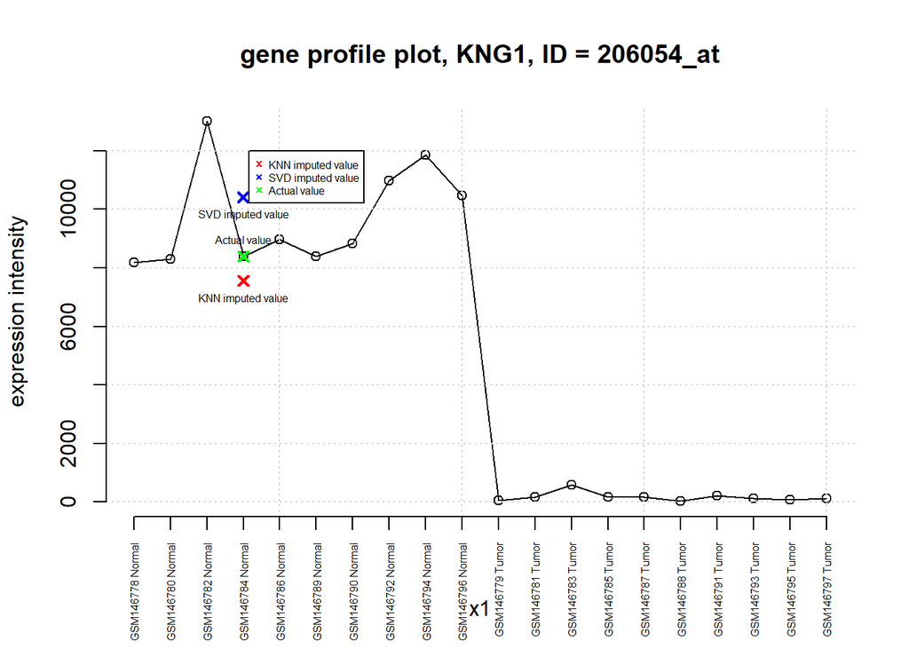

```r
plot(x1, as.numeric(KNG1_1), ylab="expression intensity",
    main="gene profile plot, KNG1, ID = 206054_at", axes=F
    ) + lines(x1, as.numeric(KNG1_1)) + grid()
axis(1, at=x1, labels=samples, las=2, cex.lab=0.4, cex.axis=0.5)
axis(2)

# Color the two imputed values and the Actual value
x_arr <- match("GSM146784 Normal", colnames(missing_dat))
# Actual value
points(x_arr, actual_value, col = "green", pch=4, lwd=2)
text(x_arr, actual_value, label="Actual value", pos=3, cex=0.5)
# KNN imputed value
points(x_arr, knn_value, col = "red", pch=4, lwd=2)
text(x_arr, knn_value, label="KNN imputed value", pos=1, cex=0.5)
# SVD imputed value
points(x_arr, svd_value, col = "blue", pch=4, lwd=2)
text(x_arr, svd_value, label="SVD imputed value", pos=1, cex=0.5)

legend(1, 12000,
  legend=c("KNN imputed value","SVD imputed value","Actual value"),
  col=c("red","blue","green"), pch=4, cex=0.5, xjust=-1, yjust=1)
```